# Data analysis tmdb-movies

## Team members:

### Shimaa esmat

### Kareem Adel

### Abdulrahman Sleem

# Introduction

## Overview

This data set contains information about 10 thousand movies collected from The Movie Database (TMDb), including user ratings and revenue. It consist of 21 columns such as id ,imdb_id ,popularity ,budget ,revenue ,original_title ,cast ,homepage ,director ,tagline ,overview ,runtime ,genres ,production_companies ,release_date ,vote_count ,vote_average ,release_year ,budget_adj ,revenue_adj

## Question that can analyised from this data set

Movies with most and least earned revenu.

In which year we had most no.of profit movies.

Average budget (with respest to the profitable movies)

What kinds of properties are associated with movies that have high revenues?

Most frequent cast (with respest to the profitable movies)

Movies which had most and least profit

Movies with longest and shortest runtime values

Successful genres (with respest to the profitable movies).

Which genres are most popular from year to year?

Movies with largest and lowest budgets

Average runtime of all the movies.

A histogram a graph that shows the frequency of numerical data

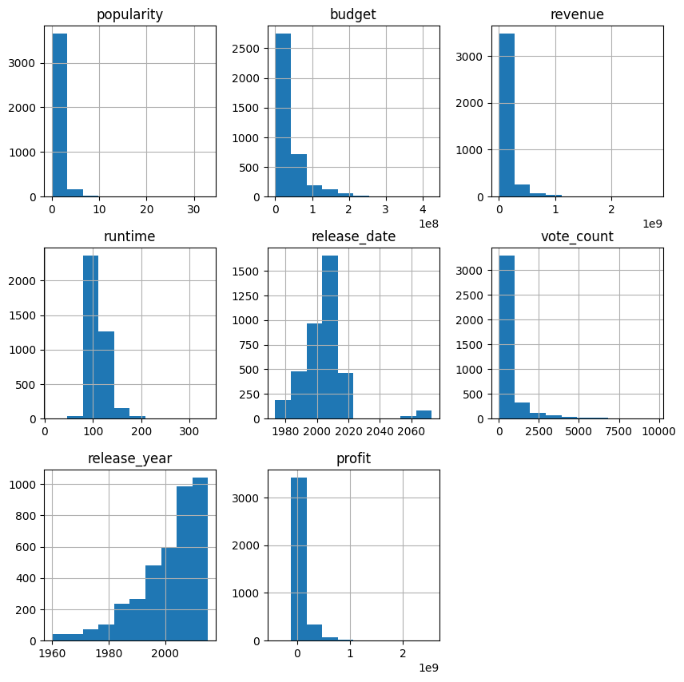

# Question 1 : Movies with most and least earned revenu

Avatar shows the largest revenue earned which is 2781505847 dollar

Whereas Shattered Glass and Mallrats shows the smallest revenue which is 2 dollar

# Question 2 : In which year we had the highest profit movies?

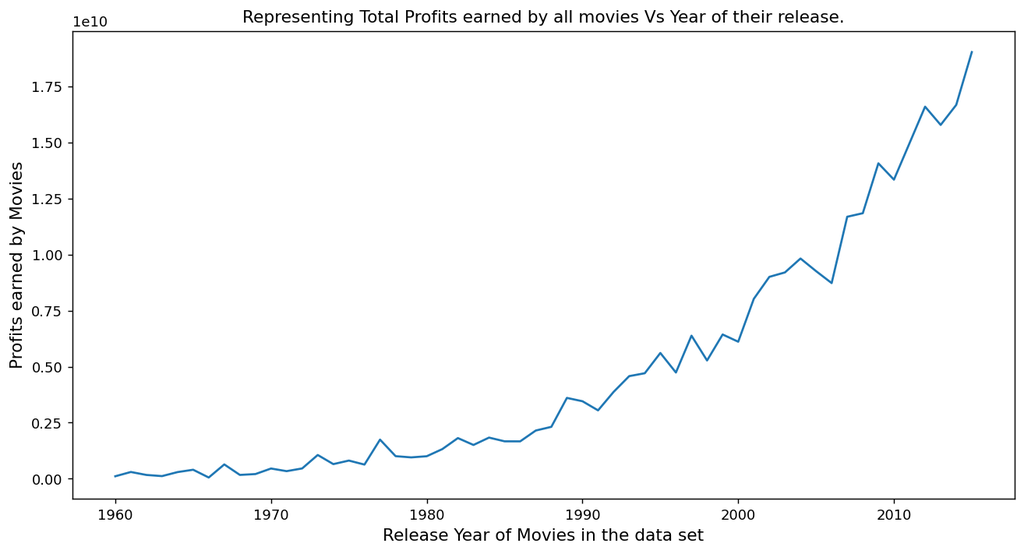

So we can conclude that year 2015 was the year where movies made the highest profit

# Question 3 : Average budget (with respest to the profitable movies)

the movies having profit of 40 million dollar and more have an average budget of 60 million dollar.

# Question 4 : What kinds of properties are associated with movies that have high revenues?

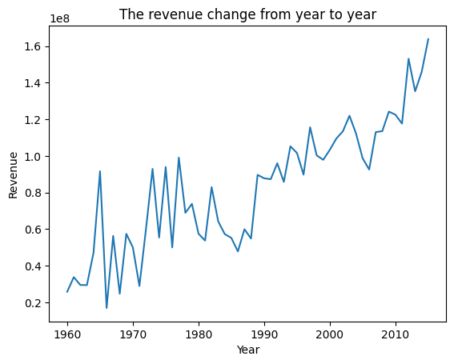

This line chart shows The revenue change over the years

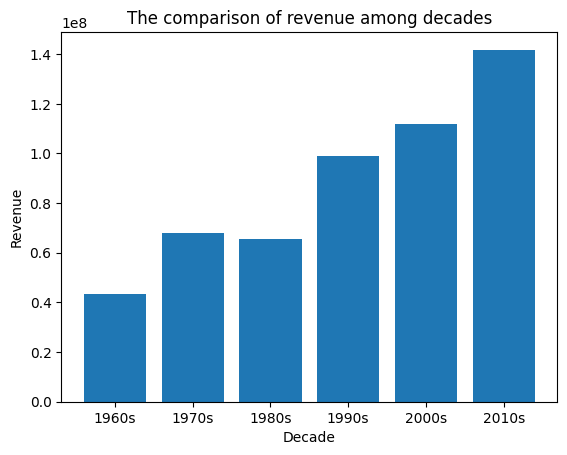

The comparison of revenue among decades From the bar char above, the revenue increased over the year. The 2010s accounts for the most, while the 1960s accounts for the least.

The correlation of 0.56 is relatively high for these two variables budget and revenue.

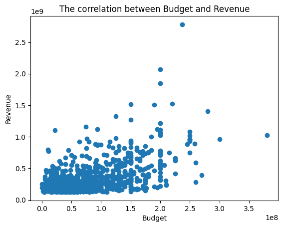

|  | budget | revenue |
| --- | --- | --- |
| budget | 1.00000 | 0.55703 |
| revenue | 0.55703 | 1.00000 |

The correlation between these popularity and revenue is 0.51, a relatively high figure

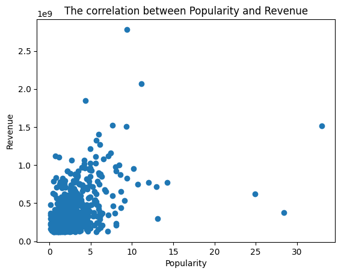

|  | popularity | revenue |
| --- | --- | --- |
| popularity | 1.000000 | 0.511673 |
| revenue | 0.511673 | 1.000000 |

|  | popularity | budget | revenue | original_title | cast | director | tagline | runtime | genres | release_date | vote_count | release_year | profit | decade |
| --- | --- | --- | --- | --- | --- | --- | --- | --- | --- | --- | --- | --- | --- | --- |
| popularity | 1.000000 | 0.313969 | 0.511673 | 1.0 | NaN | NaN | NaN | 0.221397 | NaN | 0.209848 | 0.695962 | 0.224221 | 0.493021 | NaN |
| budget | 0.313969 | 1.000000 | 0.557030 | 1.0 | NaN | NaN | NaN | 0.222530 | NaN | 0.289708 | 0.449175 | 0.424115 | 0.370724 | NaN |
| revenue | 0.511673 | 0.557030 | 1.000000 | 1.0 | NaN | NaN | NaN | 0.246599 | NaN | 0.114192 | 0.676351 | 0.172144 | 0.977818 | NaN |
| original_title | 1.000000 | 1.000000 | 1.000000 | 1.0 | NaN | NaN | NaN | 1.000000 | NaN | 1.000000 | 1.000000 | 1.000000 | 1.000000 | NaN |
| cast | NaN | NaN | NaN | NaN | NaN | NaN | NaN | NaN | NaN | NaN | NaN | NaN | NaN | NaN |
| director | NaN | NaN | NaN | NaN | NaN | NaN | NaN | NaN | NaN | NaN | NaN | NaN | NaN | NaN |
| tagline | NaN | NaN | NaN | NaN | NaN | NaN | NaN | NaN | NaN | NaN | NaN | NaN | NaN | NaN |
| runtime | 0.221397 | 0.222530 | 0.246599 | 1.0 | NaN | NaN | NaN | 1.000000 | NaN | -0.056945 | 0.320553 | -0.084156 | 0.219649 | NaN |
| genres | NaN | NaN | NaN | NaN | NaN | NaN | NaN | NaN | NaN | NaN | NaN | NaN | NaN | NaN |
| release_date | 0.209848 | 0.289708 | 0.114192 | 1.0 | NaN | NaN | NaN | -0.056945 | NaN | 1.000000 | 0.248549 | 0.616558 | 0.054636 | NaN |
| vote_count | 0.695962 | 0.449175 | 0.676351 | 1.0 | NaN | NaN | NaN | 0.320553 | NaN | 0.248549 | 1.000000 | 0.292262 | 0.643082 | NaN |
| release_year | 0.224221 | 0.424115 | 0.172144 | 1.0 | NaN | NaN | NaN | -0.084156 | NaN | 0.616558 | 0.292262 | 1.000000 | 0.085545 | NaN |
| profit | 0.493021 | 0.370724 | 0.977818 | 1.0 | NaN | NaN | NaN | 0.219649 | NaN | 0.054636 | 0.643082 | 0.085545 | 1.000000 | NaN |
| decade | NaN | NaN | NaN | NaN | NaN | NaN | NaN | NaN | NaN | NaN | NaN | NaN | NaN | NaN |

Overall, for the high revenue group, the revenue is related to the 'popularity' and 'budget' , less related to 'run time' and 'release date'

## 5- Most frequent cast (with respest to the profitable movies)

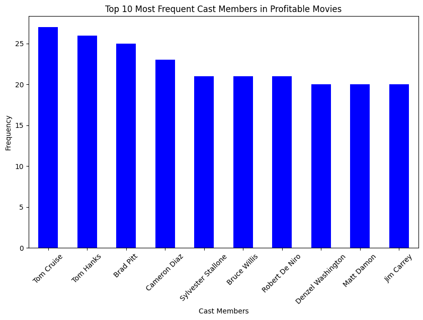

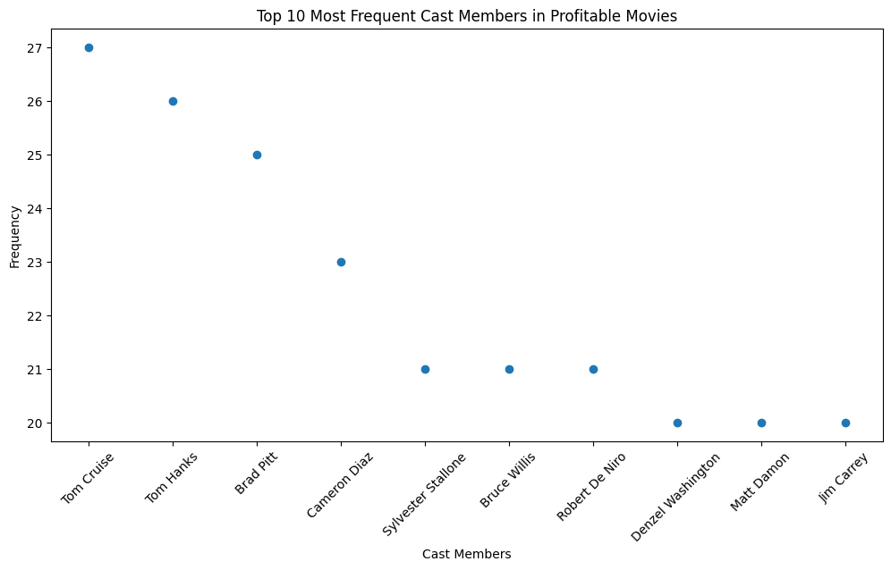

Any one of these should be in the cast :Tom Cruise, Brad Pitt, Tom Hanks, Sylvester Stallone,Cameron Diaz

# 6- Movies which had most and least profit

the move with hightest profit is Avatar , the lowest is The Warrior's Way

Avatar shows the highest earned profit i.e 2544505847 . Whereas The Warrior's Way shows the lowest earned profit i.e -413912431

# 7- Movies with longest and shortest runtime values

'Carlos' movie shows the longest runtime = 338 minutes.

Whereas 'The Kid's Story' movie shows the shortest runtime = 15 minutes

# 8- Successful genres that have high profit

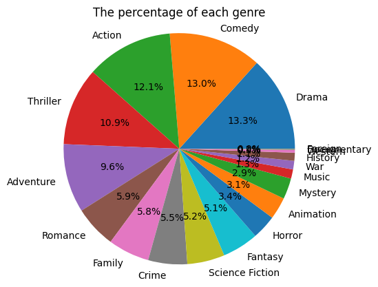

from the pie chart and analysis Drama is the most profit genre

## 9- Which genres are most popular from year to year?

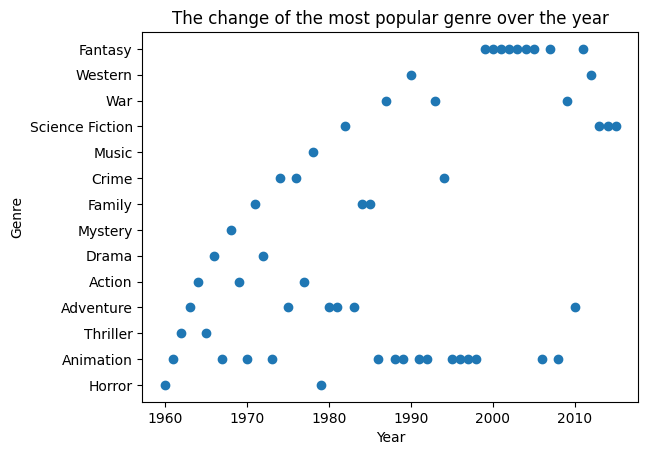

From the scatterplot above, it is easy to show that the most popular genre changed over the year. However, in some periods there are no or little changes. Overall, the most popular genre in 1990s is animation, while it becomes fantasy in 2000s.

## 10- Movies with largest and lowest budgets

[figure not shown]

[figure not shown]

[figure not shown]

## 11- Average runtime of all the movies.

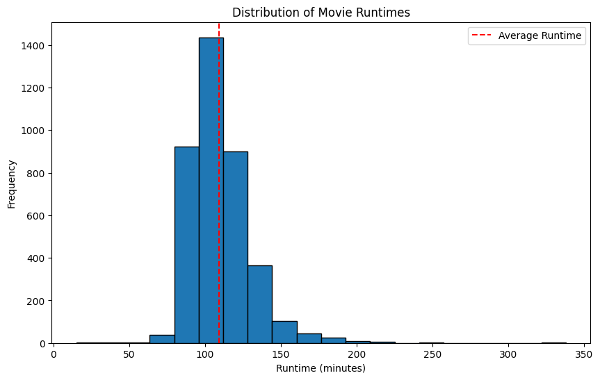

The distribution of the above formed graph is positively skewed or right skewed! Most of the movies are timed between 80 to 115 minutes. Almost 1000 and more no.of movies fall in this criteria.

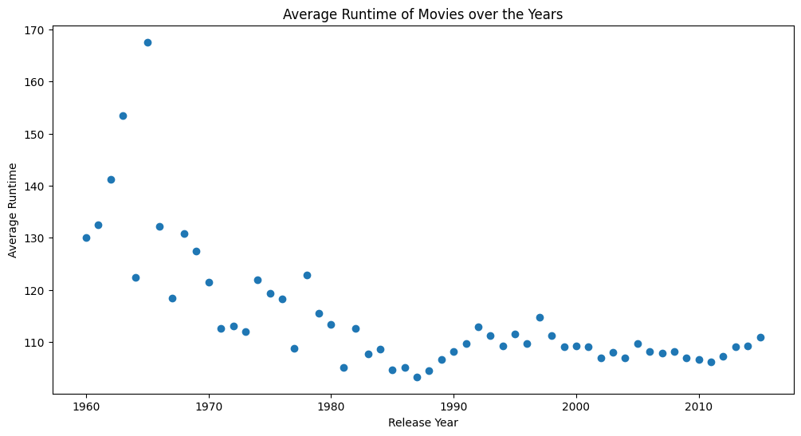

## Conclusions

This was a very interesting data analysis. We came out with some very interesting facts about movies. After this analysis we can conclude following

### For a Movie to be in successful criteria

Average Budget must be around 60 millon dollar

Average duration of the movie must be 109 minutes

Any one of these should be in the cast :Tom Cruise, Brad Pitt, Tom Hanks, Sylvester Stallone,Cameron Diaz

Genre must be : Action, Adventure, Thriller, Comedy, Drama

### Notes must be considered

The revenue changed drastically over the year but showed an overall increase. The 1960s accounts for the least, while the 2010s accounts for the most.

The most popular genre of the movie changed over the year, although it shows the stability in some periods. Over the year, animation, fantasy, and adventure account for a large proportion of the most popular genre.

###### The limitation of this research is that there are so many data that have been cleaned in this report. These datas are seen as anomalies since they contains NaN, duplicates, or 0 in some or all columns. The amount of data changed from 10866 to 3854. The change is huge so that the results may not represent the population